# monet-cyclegan (3)

## Monet GAN

The objective of this competition is to transform photographs into monet style paintings. This will be achieved using GANs and a combination of generator and discrimiator models.

```python
!pip install tensorflow==2.17.0


import pandas as pd
import numpy as np
import tensorflow as tf
import tensorflow_datasets as tfds

import os
import time
import matplotlib.pyplot as plt
from IPython.display import clear_output

from kaggle_datasets import KaggleDatasets

AUTOTUNE = tf.data.AUTOTUNE


from tensorflow import keras
from tensorflow.keras import layers

from IPython.display import display, clear_output


print(tf.__version__)
```

[output not shown]

[output not shown]

```
2.17.0
```

```python
try:
    tpu = tf.distribute.cluster_resolver.TPUClusterResolver()
    print('Device:', tpu.master())
    tf.config.experimental_connect_to_cluster(tpu)
    tf.tpu.experimental.initialize_tpu_system(tpu)
    strategy = tf.distribute.experimental.TPUStrategy(tpu)
except:
    strategy = tf.distribute.get_strategy()
print('Number of replicas:', strategy.num_replicas_in_sync)
```

```
Number of replicas: 1
```

### The Data

The dataset is in 4 folders. 2 contain TFRecord files and the other 2 contain jpg files. One of the TFRecord and JPG folders will contain images of Monet paintings and the other 2 will contain images of real-world photographs.

There are 300 Monet JPG images and 7038 Photos

The dataset can be downloaded after joining the competition from the following link: https://www.kaggle.com/competitions/gan-getting-started

```python
path = KaggleDatasets().get_gcs_path()
```

```python
monet_filenames = tf.io.gfile.glob(str(path + '/monet_tfrec/*.tfrec'))
print('Monet TFRecord Files:', len(monet_filenames))

photo_filenames = tf.io.gfile.glob(str(path + '/photo_tfrec/*.tfrec'))
print('Photo TFRecord Files:', len(photo_filenames))


monet_jpgs = tf.io.gfile.glob(str(path + '/monet_jpg/*.jpg'))
print('Monet JPG Files:', len(monet_jpgs))

photo_jpgs = tf.io.gfile.glob(str(path + '/photo_jpg/*.jpg'))
print('Photo JPG Files:', len(photo_jpgs))
```

```
Monet TFRecord Files: 5
Photo TFRecord Files: 20
Monet JPG Files: 300
Photo JPG Files: 7038
```

```python
IMAGE_SIZE = [256, 256]
```

Helper functions to load the images into a dataset. This function will used to create a monet dataset and a photos dataset.

```python
def decode_image(image):
    image = tf.image.decode_jpeg(image, channels=3)
    image = (tf.cast(image, tf.float32) / 127.5) - 1
    image = tf.reshape(image, [*IMAGE_SIZE, 3])
    return image

def read_tfrecord(example):
    tfrecord_format = {
        "image_name": tf.io.FixedLenFeature([], tf.string),
        "image": tf.io.FixedLenFeature([], tf.string),
        "target": tf.io.FixedLenFeature([], tf.string)
    }
    example = tf.io.parse_single_example(example, tfrecord_format)
    image = decode_image(example['image'])
    return image

def load_dataset(filenames, labeled=True, ordered=False):
    dataset = tf.data.TFRecordDataset(filenames)
    dataset = dataset.map(read_tfrecord, num_parallel_calls=AUTOTUNE)
    return dataset
```

```python
monet_ds = load_dataset(monet_filenames).batch(1)
photo_ds = load_dataset(photo_filenames).batch(1)
```

[output not shown]

Looking at an example of a monet and a photo

```python
example_monet = next(iter(monet_ds))
example_photo = next(iter(photo_ds))
```

[figure not shown]

```python
plt.subplot(121)
plt.title('Photo')
plt.imshow(example_photo[0] * 0.5 + 0.5)

plt.subplot(122)
plt.title('Monet')
plt.imshow(example_monet[0] * 0.5 + 0.5)
```

The below function will create 3 histograms for each color (red, blue, and green) to show how much of that color is present in a given image. I will then call the function to look at examples of 4 monets and 4 photos.

```python
import cv2

#function to plot a histogram of the colors (r,g,b) in an image
def color_hist_vis(filepath, figsize=(8, 2)):
    plt.figure(figsize=figsize)

    image = cv2.imread(filepath)
    image = cv2.cvtColor(image, cv2.COLOR_BGR2RGB)
    plt.subplot(1,4,1)
    plt.imshow(image)
    plt.axis("off")

    colors = ["red", "green", "blue"]
    n = len(colors)
    for i in range(n):
        plt.subplot(1,4,i+2)
        plt.hist(
            image[:,:,i].reshape(-1),
            bins=20,
            alpha=.5,
            color=colors[i],
            density=True
        )
        plt.xlim(0,255)
        plt.xticks([])
        plt.yticks([])
    plt.show()
```

[figure not shown]

[figure not shown]

[figure not shown]

[figure not shown]

```python
#check out color histogram for some monets
color_hist_vis("/kaggle/input/gan-getting-started/monet_jpg/000c1e3bff.jpg")
color_hist_vis("/kaggle/input/gan-getting-started/monet_jpg/058f878b7c.jpg")
color_hist_vis("/kaggle/input/gan-getting-started/monet_jpg/17557a29cb.jpg")
color_hist_vis("/kaggle/input/gan-getting-started/monet_jpg/1994b8d4a2.jpg")
```

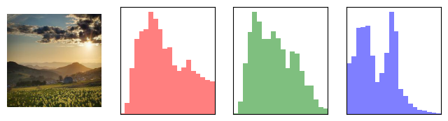

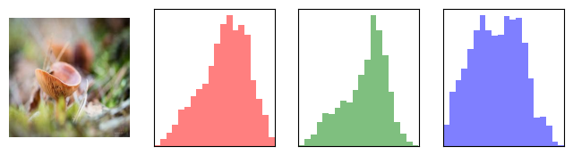

[figure not shown]

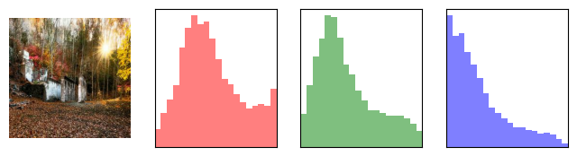

```python
#check out color histogram for some photos
color_hist_vis("/kaggle/input/gan-getting-started/photo_jpg/00068bc07f.jpg")
color_hist_vis("/kaggle/input/gan-getting-started/photo_jpg/0033c5f971.jpg")
color_hist_vis("/kaggle/input/gan-getting-started/photo_jpg/0080f94ebc.jpg")
color_hist_vis("/kaggle/input/gan-getting-started/photo_jpg/01416e7ada.jpg")
```

## Building the model

The first model is a CycleGAN model, which requires generator and discriminator functions which are defined below along with helper functions (downsample and upsample) that will be used within each.

```python
OUTPUT_CHANNELS = 3

def downsample(filters, size, apply_instancenorm=True):
    initializer = tf.random_normal_initializer(0., 0.02)
    gamma_init = keras.initializers.RandomNormal(mean=0.0, stddev=0.02)

    result = keras.Sequential()
    result.add(layers.Conv2D(filters, size, strides=2, padding='same',
                             kernel_initializer=initializer, use_bias=False))

    if apply_instancenorm:
        result.add(tf.keras.layers.GroupNormalization(gamma_initializer=gamma_init))

    result.add(layers.LeakyReLU())

    return result
```

```python
def upsample(filters, size, apply_dropout=False):
    initializer = tf.random_normal_initializer(0., 0.02)
    gamma_init = keras.initializers.RandomNormal(mean=0.0, stddev=0.02)

    result = keras.Sequential()
    result.add(layers.Conv2DTranspose(filters, size, strides=2,
                                      padding='same',
                                      kernel_initializer=initializer,
                                      use_bias=False))

    result.add(tf.keras.layers.GroupNormalization(gamma_initializer=gamma_init))

    if apply_dropout:
        result.add(layers.Dropout(0.5))

    result.add(layers.ReLU())

    return result
```

```python
def Generator():
    inputs = layers.Input(shape=[256,256,3])

    # bs = batch size
    down_stack = [
        downsample(64, 4, apply_instancenorm=False), # (bs, 128, 128, 64)
        downsample(128, 4), # (bs, 64, 64, 128)
        downsample(256, 4), # (bs, 32, 32, 256)
        downsample(512, 4), # (bs, 16, 16, 512)
        downsample(512, 4), # (bs, 8, 8, 512)
        downsample(512, 4), # (bs, 4, 4, 512)
        downsample(512, 4), # (bs, 2, 2, 512)
        downsample(512, 4), # (bs, 1, 1, 512)
    ]

    up_stack = [
        upsample(512, 4, apply_dropout=True), # (bs, 2, 2, 1024)
        upsample(512, 4, apply_dropout=True), # (bs, 4, 4, 1024)
        upsample(512, 4, apply_dropout=True), # (bs, 8, 8, 1024)
        upsample(512, 4), # (bs, 16, 16, 1024)
        upsample(256, 4), # (bs, 32, 32, 512)
        upsample(128, 4), # (bs, 64, 64, 256)
        upsample(64, 4), # (bs, 128, 128, 128)
    ]

    initializer = tf.random_normal_initializer(0., 0.02)
    last = layers.Conv2DTranspose(OUTPUT_CHANNELS, 4,
                                  strides=2,
                                  padding='same',
                                  kernel_initializer=initializer,
                                  activation='tanh') # (bs, 256, 256, 3)

    x = inputs

    # Downsampling through the model
    skips = []
    for down in down_stack:
        x = down(x)
        skips.append(x)

    skips = reversed(skips[:-1])

    # Upsampling and establishing the skip connections
    for up, skip in zip(up_stack, skips):
        x = up(x)
        x = layers.Concatenate()([x, skip])

    x = last(x)

    return keras.Model(inputs=inputs, outputs=x)
```

```python
def Discriminator():
    initializer = tf.random_normal_initializer(0., 0.02)
    gamma_init = keras.initializers.RandomNormal(mean=0.0, stddev=0.02)

    inp = layers.Input(shape=[256, 256, 3], name='input_image')

    x = inp

    down1 = downsample(64, 4, False)(x) # (bs, 128, 128, 64)
    down2 = downsample(128, 4)(down1) # (bs, 64, 64, 128)
    down3 = downsample(256, 4)(down2) # (bs, 32, 32, 256)

    zero_pad1 = layers.ZeroPadding2D()(down3) # (bs, 34, 34, 256)
    conv = layers.Conv2D(512, 4, strides=1,
                         kernel_initializer=initializer,
                         use_bias=False)(zero_pad1) # (bs, 31, 31, 512)

    norm1 = tf.keras.layers.GroupNormalization(gamma_initializer=gamma_init)(conv)

    leaky_relu = layers.LeakyReLU()(norm1)

    zero_pad2 = layers.ZeroPadding2D()(leaky_relu) # (bs, 33, 33, 512)

    last = layers.Conv2D(1, 4, strides=1,
                         kernel_initializer=initializer)(zero_pad2) # (bs, 30, 30, 1)

    return tf.keras.Model(inputs=inp, outputs=last)
```

```python
with strategy.scope():
    monet_generator = Generator() # transforms photos to Monet-esque paintings
    photo_generator = Generator() # transforms Monet paintings to be more like photos

    monet_discriminator = Discriminator() # differentiates real Monet paintings and generated Monet paintings
    photo_discriminator = Discriminator() # differentiates real photos and generated photos
```

Creating a generator instance and testing it out.

[output not shown]

[output cut: 77 more lines]

[output not shown]

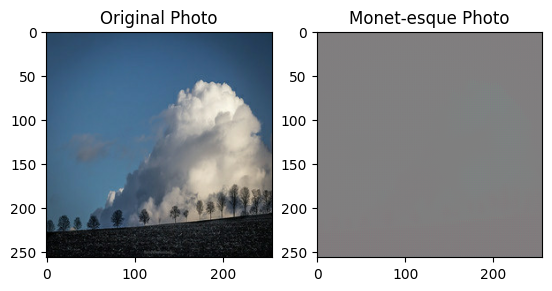

```python
to_monet = monet_generator(example_photo)

plt.subplot(1, 2, 1)
plt.title("Original Photo")
plt.imshow(example_photo[0] * 0.5 + 0.5)

plt.subplot(1, 2, 2)
plt.title("Monet-esque Photo")
plt.imshow(to_monet[0] * 0.5 + 0.5)
plt.show()
```

```python
class CycleGan(keras.Model):
    def __init__(
        self,
        monet_generator,
        photo_generator,
        monet_discriminator,
        photo_discriminator,
        lambda_cycle=10,
    ):
        super(CycleGan, self).__init__()
        self.m_gen = monet_generator
        self.p_gen = photo_generator
        self.m_disc = monet_discriminator
        self.p_disc = photo_discriminator
        self.lambda_cycle = lambda_cycle

    def compile(
        self,
        m_gen_optimizer,
        p_gen_optimizer,
        m_disc_optimizer,
        p_disc_optimizer,
        gen_loss_fn,
        disc_loss_fn,
        cycle_loss_fn,
        identity_loss_fn
    ):
        super(CycleGan, self).compile()
        self.m_gen_optimizer = m_gen_optimizer
        self.p_gen_optimizer = p_gen_optimizer
        self.m_disc_optimizer = m_disc_optimizer
        self.p_disc_optimizer = p_disc_optimizer
        self.gen_loss_fn = gen_loss_fn
        self.disc_loss_fn = disc_loss_fn
        self.cycle_loss_fn = cycle_loss_fn
        self.identity_loss_fn = identity_loss_fn

    def train_step(self, batch_data):
        real_monet, real_photo = batch_data

        with tf.GradientTape(persistent=True) as tape:
            # photo to monet back to photo
            fake_monet = self.m_gen(real_photo, training=True)
            print('fake monet shape: ', fake_monet.shape)
            cycled_photo = self.p_gen(fake_monet, training=True)

            # monet to photo back to monet
            fake_photo = self.p_gen(real_monet, training=True)
            cycled_monet = self.m_gen(fake_photo, training=True)

            # generating itself
            same_monet = self.m_gen(real_monet, training=True)
            same_photo = self.p_gen(real_photo, training=True)

            # discriminator used to check, inputing real images
            disc_real_monet = self.m_disc(real_monet, training=True)
            disc_real_photo = self.p_disc(real_photo, training=True)

            # discriminator used to check, inputing fake images
            disc_fake_monet = self.m_disc(fake_monet, training=True)
            disc_fake_photo = self.p_disc(fake_photo, training=True)

            # evaluates generator loss
            monet_gen_loss = self.gen_loss_fn(disc_fake_monet)
            photo_gen_loss = self.gen_loss_fn(disc_fake_photo)

            # evaluates total cycle consistency loss
            total_cycle_loss = self.cycle_loss_fn(real_monet, cycled_monet, self.lambda_cycle) + self.cycle_loss_fn(real_photo, cycled_photo, self.lambda_cycle)

            # evaluates total generator loss
            total_monet_gen_loss = monet_gen_loss + total_cycle_loss + self.identity_loss_fn(real_monet, same_monet, self.lambda_cycle)
            total_photo_gen_loss = photo_gen_loss + total_cycle_loss + self.identity_loss_fn(real_photo, same_photo, self.lambda_cycle)

            # evaluates discriminator loss
            monet_disc_loss = self.disc_loss_fn(disc_real_monet, disc_fake_monet)
            photo_disc_loss = self.disc_loss_fn(disc_real_photo, disc_fake_photo)

        # Calculate the gradients for generator and discriminator
        monet_generator_gradients = tape.gradient(total_monet_gen_loss,
                                                  self.m_gen.trainable_variables)
        photo_generator_gradients = tape.gradient(total_photo_gen_loss,
                                                  self.p_gen.trainable_variables)

        monet_discriminator_gradients = tape.gradient(monet_disc_loss,
                                                      self.m_disc.trainable_variables)
        photo_discriminator_gradients = tape.gradient(photo_disc_loss,
                                                      self.p_disc.trainable_variables)

        # Apply the gradients to the optimizer
        self.m_gen_optimizer.apply_gradients(zip(monet_generator_gradients,
                                                 self.m_gen.trainable_variables))

        self.p_gen_optimizer.apply_gradients(zip(photo_generator_gradients,
                                                 self.p_gen.trainable_variables))

        self.m_disc_optimizer.apply_gradients(zip(monet_discriminator_gradients,
                                                  self.m_disc.trainable_variables))

        self.p_disc_optimizer.apply_gradients(zip(photo_discriminator_gradients,
                                                  self.p_disc.trainable_variables))

        return {
            "monet_gen_loss": total_monet_gen_loss,
            "photo_gen_loss": total_photo_gen_loss,
            "monet_disc_loss": monet_disc_loss,
            "photo_disc_loss": photo_disc_loss
        }
```

```python
with strategy.scope():
    def discriminator_loss(real, generated):
        real_loss = tf.keras.losses.BinaryCrossentropy(from_logits=True, reduction=tf.keras.losses.Reduction.NONE)(tf.ones_like(real), real)

        generated_loss = tf.keras.losses.BinaryCrossentropy(from_logits=True, reduction=tf.keras.losses.Reduction.NONE)(tf.zeros_like(generated), generated)

        total_disc_loss = real_loss + generated_loss

        return total_disc_loss * 0.5
```

```python
with strategy.scope():
    def generator_loss(generated):
        return tf.keras.losses.BinaryCrossentropy(from_logits=True, reduction=tf.keras.losses.Reduction.NONE)(tf.ones_like(generated), generated)
```

```python
with strategy.scope():
    def calc_cycle_loss(real_image, cycled_image, LAMBDA):
        loss1 = tf.reduce_mean(tf.abs(real_image - cycled_image))

        return LAMBDA * loss1
```

```python
with strategy.scope():
    def identity_loss(real_image, same_image, LAMBDA):
        loss = tf.reduce_mean(tf.abs(real_image - same_image))
        return LAMBDA * 0.5 * loss
```

```python
with strategy.scope():
    monet_generator_optimizer = tf.keras.optimizers.Adam(2e-4, beta_1=0.5)
    photo_generator_optimizer = tf.keras.optimizers.Adam(2e-4, beta_1=0.5)

    monet_discriminator_optimizer = tf.keras.optimizers.Adam(2e-4, beta_1=0.5)
    photo_discriminator_optimizer = tf.keras.optimizers.Adam(2e-4, beta_1=0.5)
```

```python
with strategy.scope():
    cycle_gan_model = CycleGan(
        monet_generator, photo_generator, monet_discriminator, photo_discriminator
    )

    cycle_gan_model.compile(
        m_gen_optimizer = monet_generator_optimizer,
        p_gen_optimizer = photo_generator_optimizer,
        m_disc_optimizer = monet_discriminator_optimizer,
        p_disc_optimizer = photo_discriminator_optimizer,
        gen_loss_fn = generator_loss,
        disc_loss_fn = discriminator_loss,
        cycle_loss_fn = calc_cycle_loss,
        identity_loss_fn = identity_loss
    )
```

```python
#fitting the model to our dataset
history = cycle_gan_model.fit(
    tf.data.Dataset.zip((monet_ds, photo_ds)),
    epochs=25
)
```

```
300/300 ━━━━━━━━━━━━━━━━━━━━ 46s 149ms/step - monet_disc_loss: 0.6345 - monet_gen_loss: 2.4117 - photo_disc_loss: 0.5935 - photo_gen_loss: 2.5056
300/300 ━━━━━━━━━━━━━━━━━━━━ 46s 149ms/step - monet_disc_loss: 0.6371 - monet_gen_loss: 2.4274 - photo_disc_loss: 0.5910 - photo_gen_loss: 2.5266
300/300 ━━━━━━━━━━━━━━━━━━━━ 46s 149ms/step - monet_disc_loss: 0.6264 - monet_gen_loss: 2.4492 - photo_disc_loss: 0.5958 - photo_gen_loss: 2.5143
300/300 ━━━━━━━━━━━━━━━━━━━━ 46s 149ms/step - monet_disc_loss: 0.6361 - monet_gen_loss: 2.4413 - photo_disc_loss: 0.5998 - photo_gen_loss: 2.5110
300/300 ━━━━━━━━━━━━━━━━━━━━ 46s 149ms/step - monet_disc_loss: 0.6383 - monet_gen_loss: 2.4097 - photo_disc_loss: 0.6002 - photo_gen_loss: 2.4955
300/300 ━━━━━━━━━━━━━━━━━━━━ 46s 149ms/step - monet_disc_loss: 0.6363 - monet_gen_loss: 2.4144 - photo_disc_loss: 0.6085 - photo_gen_loss: 2.4757
300/300 ━━━━━━━━━━━━━━━━━━━━ 46s 149ms/step - monet_disc_loss: 0.6290 - monet_gen_loss: 2.4760 - photo_disc_loss: 0.5979 - photo_gen_loss: 2.5439
300/300 ━━━━━━━━━━━━━━━━━━━━ 46s 149ms/step - monet_disc_loss: 0.6398 - monet_gen_loss: 2.4167 - photo_disc_loss: 0.6113 - photo_gen_loss: 2.4802
300/300 ━━━━━━━━━━━━━━━━━━━━ 46s 149ms/step - monet_disc_loss: 0.6233 - monet_gen_loss: 2.4554 - photo_disc_loss: 0.5959 - photo_gen_loss: 2.5189
300/300 ━━━━━━━━━━━━━━━━━━━━ 46s 149ms/step - monet_disc_loss: 0.6275 - monet_gen_loss: 2.4431 - photo_disc_loss: 0.6019 - photo_gen_loss: 2.5058
300/300 ━━━━━━━━━━━━━━━━━━━━ 46s 149ms/step - monet_disc_loss: 0.6222 - monet_gen_loss: 2.4637 - photo_disc_loss: 0.6006 - photo_gen_loss: 2.5019
300/300 ━━━━━━━━━━━━━━━━━━━━ 46s 149ms/step - monet_disc_loss: 0.6271 - monet_gen_loss: 2.4624 - photo_disc_loss: 0.6000 - photo_gen_loss: 2.5352
300/300 ━━━━━━━━━━━━━━━━━━━━ 46s 149ms/step - monet_disc_loss: 0.6362 - monet_gen_loss: 2.4599 - photo_disc_loss: 0.6019 - photo_gen_loss: 2.5297
300/300 ━━━━━━━━━━━━━━━━━━━━ 46s 149ms/step - monet_disc_loss: 0.6270 - monet_gen_loss: 2.4640 - photo_disc_loss: 0.6083 - photo_gen_loss: 2.5099
300/300 ━━━━━━━━━━━━━━━━━━━━ 46s 149ms/step - monet_disc_loss: 0.6216 - monet_gen_loss: 2.4532 - photo_disc_loss: 0.6047 - photo_gen_loss: 2.4855
300/300 ━━━━━━━━━━━━━━━━━━━━ 46s 149ms/step - monet_disc_loss: 0.6147 - monet_gen_loss: 2.4896 - photo_disc_loss: 0.5949 - photo_gen_loss: 2.5063
300/300 ━━━━━━━━━━━━━━━━━━━━ 46s 149ms/step - monet_disc_loss: 0.6279 - monet_gen_loss: 2.4442 - photo_disc_loss: 0.6019 - photo_gen_loss: 2.5071
300/300 ━━━━━━━━━━━━━━━━━━━━ 46s 149ms/step - monet_disc_loss: 0.6202 - monet_gen_loss: 2.4586 - photo_disc_loss: 0.6062 - photo_gen_loss: 2.5063
300/300 ━━━━━━━━━━━━━━━━━━━━ 46s 149ms/step - monet_disc_loss: 0.6196 - monet_gen_loss: 2.4560 - photo_disc_loss: 0.6024 - photo_gen_loss: 2.4759
300/300 ━━━━━━━━━━━━━━━━━━━━ 46s 149ms/step - monet_disc_loss: 0.6207 - monet_gen_loss: 2.4700 - photo_disc_loss: 0.6017 - photo_gen_loss: 2.5171
300/300 ━━━━━━━━━━━━━━━━━━━━ 46s 149ms/step - monet_disc_loss: 0.6126 - monet_gen_loss: 2.5478 - photo_disc_loss: 0.6004 - photo_gen_loss: 2.5495
300/300 ━━━━━━━━━━━━━━━━━━━━ 46s 149ms/step - monet_disc_loss: 0.6165 - monet_gen_loss: 2.4876 - photo_disc_loss: 0.5856 - photo_gen_loss: 2.5463
300/300 ━━━━━━━━━━━━━━━━━━━━ 46s 149ms/step - monet_disc_loss: 0.6214 - monet_gen_loss: 2.4758 - photo_disc_loss: 0.5878 - photo_gen_loss: 2.5559
300/300 ━━━━━━━━━━━━━━━━━━━━ 46s 149ms/step - monet_disc_loss: 0.6117 - monet_gen_loss: 2.4409 - photo_disc_loss: 0.5981 - photo_gen_loss: 2.4815
300/300 ━━━━━━━━━━━━━━━━━━━━ 46s 149ms/step - monet_disc_loss: 0.6285 - monet_gen_loss: 2.4524 - photo_disc_loss: 0.5970 - photo_gen_loss: 2.5334
```

looking at some of the monet photos that we were able to generate

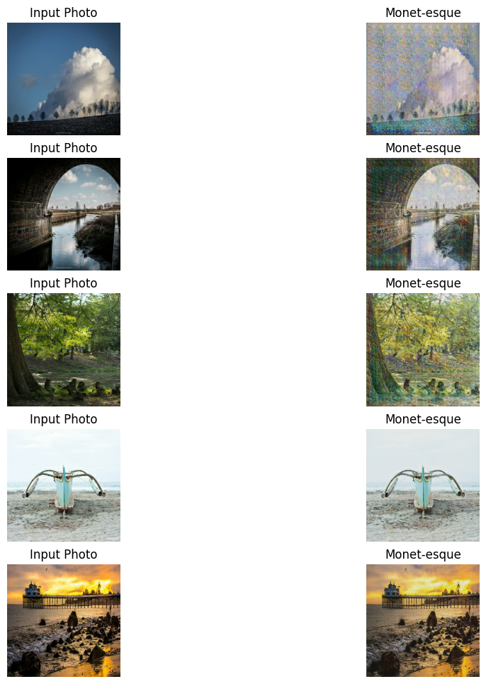

```python
_, ax = plt.subplots(5, 2, figsize=(12, 12))
for i, img in enumerate(photo_ds.take(5)):
    prediction = monet_generator(img, training=False)[0].numpy()
    prediction = (prediction * 127.5 + 127.5).astype(np.uint8)
    img = (img[0] * 127.5 + 127.5).numpy().astype(np.uint8)

    ax[i, 0].imshow(img)
    ax[i, 1].imshow(prediction)
    ax[i, 0].set_title("Input Photo")
    ax[i, 1].set_title("Monet-esque")
    ax[i, 0].axis("off")
    ax[i, 1].axis("off")
plt.show()
```

Generate monets from photo dataset and create the submission file.

```python
import PIL
! mkdir ../images
```

```python
i = 1
for img in photo_ds:
    prediction = monet_generator(img, training=False)[0].numpy()
    prediction = (prediction * 127.5 + 127.5).astype(np.uint8)
    im = PIL.Image.fromarray(prediction)
    im.save("../images/" + str(i) + ".jpg")
    i += 1
```

```python
import shutil
shutil.make_archive("/kaggle/working/images", 'zip', "/kaggle/images")
```

```
'/kaggle/working/images.zip'
```

## Second model

I wanted to try another method for creating the model. I created a new generator and new discriminator to test.

```python
def new_generator():

    model = tf.keras.Sequential()

    #(1, 256, 256, 3)

    model.add(layers.Flatten(input_shape=(256, 256, 3,)))  # Flatten the image
    model.add(layers.Dense(100))

    model.add(layers.Dense(8*8*256, use_bias=False, input_shape=(100, )))
    model.add(layers.BatchNormalization())
    model.add(layers.LeakyReLU())

    model.add(layers.Reshape((8,8,256,)))
    assert model.output_shape == (None, 8, 8, 256)

    model.add(layers.Conv2DTranspose(128, (4,4), strides=(1,1), padding='same', use_bias=False))
    assert model.output_shape == (None, 8, 8, 128)
    model.add(layers.BatchNormalization())
    model.add(layers.LeakyReLU())


    model.add(layers.Conv2DTranspose(64, (4,4), strides=(2,2), padding='same', use_bias=False))
    assert model.output_shape == (None, 16, 16, 64)
    model.add(layers.BatchNormalization())
    model.add(layers.LeakyReLU())


    model.add(layers.Conv2DTranspose(3, (4,4), strides=(2,2),
                                     padding='same', use_bias=False,
                                     activation = 'tanh')
             )
    assert model.output_shape == (None, 32, 32, 3)

    model.add(layers.UpSampling2D(size=(8, 8), input_shape=(32, 32, 3)))

    return model
```

```python
gen = new_generator()

noise = tf.random.normal([1,100])

#gen_img = gen(noise, training=False)

#plt.imshow(gen_img[0,:,:,0])

#print("noise.......: ", type(noise))
```

```python
def new_descriminator():
    model = tf.keras.Sequential()

    model.add(layers.AveragePooling2D(pool_size=(8, 8), strides=(8, 8), input_shape=(256, 256, 3)))

    model.add(layers.Conv2D(64, (5,5), strides=(2,2), padding='same',
                           input_shape=[32,32,3]))

    model.add(layers.LeakyReLU())
    model.add(layers.Dropout(0.3))


    model.add(layers.Conv2D(128, (5,5), strides=(2,2), padding='same'))
    model.add(layers.LeakyReLU())
    model.add(layers.Dropout(0.3))

    model.add(layers.Flatten())
    model.add(layers.Dense(3))

    return model
```

```python
descriminator = new_descriminator()
#dec = descriminator(gen_img)
#print(dec)
```

```python
cross_entropy = tf.keras.losses.BinaryCrossentropy(from_logits=True)
```

```python
def disc_loss(real, fake):
    real_loss = cross_entropy(tf.ones_like(real), real)
    fake_loss = cross_entropy(tf.ones_like(fake), fake)
    loss = real_loss + fake_loss
    return loss
```

```python
def gen_loss(fake):
    return cross_entropy(tf.ones_like(fake), fake)
```

```python
gen_optimizer = tf.keras.optimizers.Adam(1e-4)
disc_optimizer = tf.keras.optimizers.Adam(1e-4)
```

```python
EPOCHS = 100
noise_dim = 100
num_to_gen = 16
BATCH_SIZE = 1

seed = tf.random.normal([num_to_gen, noise_dim])
```

```python
@tf.function

def train_step(images):
    noise = tf.random.normal([BATCH_SIZE, noise_dim])

    with tf.GradientTape() as gen_tape, tf.GradientTape() as disc_tape:
        gen_images = gen(noise, training=True)
        real = descriminator(images, training=True)
        fake = descriminator(gen_images, training=True)

        g_loss = gen_loss(fake)
        desc_loss = disc_loss(real, fake)

    gen_gradients = gen_tape.gradient(g_loss, gen.trainable_variables)
    desc_gradients = disc_tape.gradient(desc_loss, descriminator.trainable_variables)

    gen_optimizer.apply_gradients(zip(gen_gradients, gen.trainable_variables))
    disc_optimizer.apply_gradients(zip(desc_gradients, descriminator.trainable_variables))
```

```python
def train(data, epochs):
    for epoch in range(epochs):
        start = time.time()

    for image_batch in data:
        train_step(image_batch)

    #display.clear_output(wait=True)
    generate_and_save_images(gen, epoch +1, seed)

    print('Time for epoch {} is {} sec'.format(epoch+1, time.time()-start))

    #display.clear_output(wait=True)
    generate_and_save_images(gen, epochs, seed)
```

```python
def generate_and_save_images(model, epoch, test_input):
    pred = new_cycle_gan_model(test_input, training=False)

    fig = plt.figure(figsize = (6,6))

    for i in range(pred.shape[0]):
        plt.subplot(4,4,i+1)
        img = pred[i]

        _min = np.amin(img)
        _max = np.amax(img)
        img_norm = (img-_min) * 255.0 / (_max - _min)
        img_norm = np.uint8(img_norm)

        plt.imshow(img_norm)
        plt.axis('off')

    plt.savefig('image_at_epoch_{:04d}.png'.format(epoch))
    plt.show()
```

Training the new model

```python
new_monet_generator = new_generator() # transforms photos to Monet-esque paintings
new_photo_generator = new_generator() # transforms Monet paintings to be more like photos

new_monet_discriminator = new_descriminator() # differentiates real Monet paintings and generated Monet paintings
new_photo_discriminator = new_descriminator()
```

```python
with strategy.scope():
    new_monet_generator_optimizer = tf.keras.optimizers.Adam(2e-4, beta_1=0.5)
    new_photo_generator_optimizer = tf.keras.optimizers.Adam(2e-4, beta_1=0.5)

    new_monet_discriminator_optimizer = tf.keras.optimizers.Adam(2e-4, beta_1=0.5)
    new_photo_discriminator_optimizer = tf.keras.optimizers.Adam(2e-4, beta_1=0.5)

with strategy.scope():
    new_cycle_gan_model = CycleGan(
        new_monet_generator, new_photo_generator, new_monet_discriminator, new_photo_discriminator
    )

    new_cycle_gan_model.compile(
        m_gen_optimizer = new_monet_generator_optimizer,
        p_gen_optimizer = new_photo_generator_optimizer,
        m_disc_optimizer = new_monet_discriminator_optimizer,
        p_disc_optimizer = new_photo_discriminator_optimizer,
        gen_loss_fn = generator_loss,
        disc_loss_fn = discriminator_loss,
        cycle_loss_fn = calc_cycle_loss,
        identity_loss_fn = identity_loss
    )

new_history = new_cycle_gan_model.fit(
    tf.data.Dataset.zip((monet_ds, photo_ds)),
    epochs=25
)
```

```
fake monet shape:  (None, 256, 256, 3)
fake monet shape:  (None, 256, 256, 3)
300/300 ━━━━━━━━━━━━━━━━━━━━ 29s 19ms/step - monet_disc_loss: 0.5437 - monet_gen_loss: 13.1381 - photo_disc_loss: 0.5069 - photo_gen_loss: 13.6226
300/300 ━━━━━━━━━━━━━━━━━━━━ 7s 18ms/step - monet_disc_loss: 0.5684 - monet_gen_loss: 13.0008 - photo_disc_loss: 0.5073 - photo_gen_loss: 13.5136
300/300 ━━━━━━━━━━━━━━━━━━━━ 7s 18ms/step - monet_disc_loss: 0.5647 - monet_gen_loss: 13.1161 - photo_disc_loss: 0.4765 - photo_gen_loss: 13.7027
300/300 ━━━━━━━━━━━━━━━━━━━━ 6s 17ms/step - monet_disc_loss: 0.5203 - monet_gen_loss: 13.0408 - photo_disc_loss: 0.4583 - photo_gen_loss: 13.4888
300/300 ━━━━━━━━━━━━━━━━━━━━ 7s 18ms/step - monet_disc_loss: 0.5338 - monet_gen_loss: 13.2830 - photo_disc_loss: 0.4852 - photo_gen_loss: 13.7867
300/300 ━━━━━━━━━━━━━━━━━━━━ 7s 19ms/step - monet_disc_loss: 0.5335 - monet_gen_loss: 13.0560 - photo_disc_loss: 0.4630 - photo_gen_loss: 13.5131
300/300 ━━━━━━━━━━━━━━━━━━━━ 6s 18ms/step - monet_disc_loss: 0.5279 - monet_gen_loss: 13.1682 - photo_disc_loss: 0.4708 - photo_gen_loss: 13.7506
300/300 ━━━━━━━━━━━━━━━━━━━━ 6s 17ms/step - monet_disc_loss: 0.4925 - monet_gen_loss: 12.9933 - photo_disc_loss: 0.4760 - photo_gen_loss: 13.5931
300/300 ━━━━━━━━━━━━━━━━━━━━ 7s 19ms/step - monet_disc_loss: 0.5497 - monet_gen_loss: 13.2007 - photo_disc_loss: 0.4613 - photo_gen_loss: 13.5417
300/300 ━━━━━━━━━━━━━━━━━━━━ 7s 18ms/step - monet_disc_loss: 0.4954 - monet_gen_loss: 13.2447 - photo_disc_loss: 0.5244 - photo_gen_loss: 13.7138
300/300 ━━━━━━━━━━━━━━━━━━━━ 6s 17ms/step - monet_disc_loss: 0.5071 - monet_gen_loss: 13.1623 - photo_disc_loss: 0.4562 - photo_gen_loss: 13.5992
300/300 ━━━━━━━━━━━━━━━━━━━━ 6s 17ms/step - monet_disc_loss: 0.5287 - monet_gen_loss: 13.0088 - photo_disc_loss: 0.5036 - photo_gen_loss: 13.3901
300/300 ━━━━━━━━━━━━━━━━━━━━ 6s 18ms/step - monet_disc_loss: 0.5037 - monet_gen_loss: 13.0543 - photo_disc_loss: 0.4515 - photo_gen_loss: 13.5759
300/300 ━━━━━━━━━━━━━━━━━━━━ 7s 18ms/step - monet_disc_loss: 0.4913 - monet_gen_loss: 13.2394 - photo_disc_loss: 0.4625 - photo_gen_loss: 13.7191
300/300 ━━━━━━━━━━━━━━━━━━━━ 6s 19ms/step - monet_disc_loss: 0.5278 - monet_gen_loss: 13.1644 - photo_disc_loss: 0.4669 - photo_gen_loss: 13.7358
300/300 ━━━━━━━━━━━━━━━━━━━━ 6s 17ms/step - monet_disc_loss: 0.5012 - monet_gen_loss: 12.9574 - photo_disc_loss: 0.4343 - photo_gen_loss: 13.6174
300/300 ━━━━━━━━━━━━━━━━━━━━ 6s 17ms/step - monet_disc_loss: 0.5392 - monet_gen_loss: 12.9179 - photo_disc_loss: 0.5027 - photo_gen_loss: 13.4048
300/300 ━━━━━━━━━━━━━━━━━━━━ 6s 17ms/step - monet_disc_loss: 0.5197 - monet_gen_loss: 13.2283 - photo_disc_loss: 0.4557 - photo_gen_loss: 13.7605
300/300 ━━━━━━━━━━━━━━━━━━━━ 7s 18ms/step - monet_disc_loss: 0.5305 - monet_gen_loss: 13.1949 - photo_disc_loss: 0.5108 - photo_gen_loss: 13.7368
300/300 ━━━━━━━━━━━━━━━━━━━━ 6s 18ms/step - monet_disc_loss: 0.5165 - monet_gen_loss: 13.2543 - photo_disc_loss: 0.5114 - photo_gen_loss: 13.6719
300/300 ━━━━━━━━━━━━━━━━━━━━ 7s 19ms/step - monet_disc_loss: 0.5333 - monet_gen_loss: 13.1102 - photo_disc_loss: 0.4767 - photo_gen_loss: 13.6101
300/300 ━━━━━━━━━━━━━━━━━━━━ 6s 17ms/step - monet_disc_loss: 0.5399 - monet_gen_loss: 12.8855 - photo_disc_loss: 0.4239 - photo_gen_loss: 13.4680
300/300 ━━━━━━━━━━━━━━━━━━━━ 6s 17ms/step - monet_disc_loss: 0.4663 - monet_gen_loss: 13.2193 - photo_disc_loss: 0.5114 - photo_gen_loss: 13.6174
300/300 ━━━━━━━━━━━━━━━━━━━━ 6s 18ms/step - monet_disc_loss: 0.5154 - monet_gen_loss: 13.2991 - photo_disc_loss: 0.4998 - photo_gen_loss: 13.7490
300/300 ━━━━━━━━━━━━━━━━━━━━ 7s 19ms/step - monet_disc_loss: 0.4973 - monet_gen_loss: 13.1363 - photo_disc_loss: 0.4125 - photo_gen_loss: 13.6540
```

Looking at the images that we were able to generate from the new generator

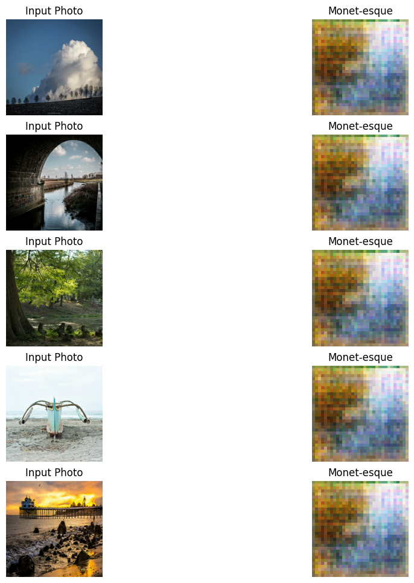

```python
_, ax = plt.subplots(5, 2, figsize=(12, 12))
for i, img in enumerate(photo_ds.take(5)):
    prediction = new_monet_generator(img, training=True)[0].numpy()
    prediction = (prediction * 127.5 + 127.5).astype(np.uint8)
    img = (img[0] * 127.5 + 127.5).numpy().astype(np.uint8)

    ax[i, 0].imshow(img)
    ax[i, 1].imshow(prediction)
    ax[i, 0].set_title("Input Photo")
    ax[i, 1].set_title("Monet-esque")
    ax[i, 0].axis("off")
    ax[i, 1].axis("off")
plt.show()
```

[figure not shown]

```python
plt.plot(new_history.history['monet_gen_loss'])
plt.plot(new_history.history['photo_gen_loss'])
plt.plot(new_history.history['monet_disc_loss'])
plt.plot(new_history.history['photo_disc_loss'])
plt.title('Generator loss')
plt.ylabel('loss')
plt.xlabel('epoch')
plt.legend(['monet gen loss', 'photo gen loss', 'monet_disc_loss', 'photo_disc_loss'], loc='upper left')
plt.show()
```